# Simulations with Tissue Specificity

The purpose is to simulate according to the patterns of sharing present in the GTEX V6 Data, where 100 snps in cis of 500 genes, $pi0$ is 0.80, and there is sharing according to gtex covmats 2:9 and about 35% tissues specific. Thus the componenet ID for the *tissue specific QTL* will be *SimulatedComponenet=9:13*.

First, install, the package. I’ve already done this:

```r
devtools::install_github("surbut/matrix_ash")
library("mash")
library("bigmemory")
library("SQUAREM")
library("mvtnorm")
```

Here, we simulate data and select the genes with maximum T statistic across tissues (here, called t, but assuming the sample size is sufficient that t is normally distributed) in order to capture the `strong patterns’ of sharing. We performs SFA on these strong Z statistics, and use these to compute the $U_{k}$ that will be used in inference. We scale each $U_{k}$ by a grid chosen according to the effect sizes present in the overall data set.

This is how we simulate data, but for the purposes of this document we will use data that has already been simulated so that the Factors and Loadings from SFA are appropriate.

```r
library("mvtnorm")
data=factor_sim_new(J = 50000,tspec=5) tissue specific tissues
saveRDS(data,"../simdata_tspec.rds")
```

Now we can read in the data. We will compute according to the ET model and corresponding covariance matrices as described in Urbut et al. Note that we use the top 400 gene snp pairs to create this covariance matrix. In later applications, we’ve run univariate ash on the whole data set and then used the maxes as the genes with a significant effect in at least one tissue, but here we simply select the 400 tops for brevity.

```r
library("mvtnorm")
data=readRDS("../simdata/simdata_tspec.rds")
t=data$tstat;bhat=data$betahat;sebetahat=data$sebetahat;beta=data$beta;s.j=matrix
c=apply(t,1,function(x){max(abs(x))})
maxes=order(c,decreasing = TRUE)[1:400]##take top gene snp pairs
max.t=t[maxes,]
##sfa -gen ./maxt.txt -g 400 -n 44 -o tri_sim_spect i -k 5

A="yourfavoritename"
factor.mat=as.matrix(read.table("../simdata/tri_sim_spect_F.out"))
lambda.mat=as.matrix(read.table("../simdata/tri_sim_spect_lambda.out"))
s.j=matrix(rep(1,ncol(t)*nrow(t)),ncol=ncol(t),nrow=nrow(t))
v.j=s.j^2
covmat=compute.covmat(b.gp.hat = t,sebetahat = s.j,Q =5, t.stat=max.t,lambda.mat=lambda.mat,P=3,A=A, factor.mat = factor.mat,bma = TRUE,zero=TRUE)$cov
```

```r
library("mash")
sum(data$component.id>8)/length(data$component.id)
```

```
## [1] 0.3475
```

Here, we can see that 0.3475of associations are tissue specific, and the tissue specific tissues are:

```r
lapply((data$component.mats[9:13]),function(x){which(diag(x)!=0)})
```

```
## [[1]]
## [1] 24
##
## [[2]]
## [1] 14
##
## [[3]]
## [1] 32
##
## [[4]]
## [1] 21
##
## [[5]]
## [1] 10
```

We can find which pairs have tissue specific activity and plot an example of their t statistic, to make sure the model is simulating correctly:

```r
(j=which(data$component.id==9)[1])
```

```
## [1] 15
```

This corresponds to tissue specificity in:

```r
diag(data$component.mats[[9]])
```

```
##  [1] 0 0 0 0 0 0 0 0 0 0 0 0 0 0 0 0 0 0 0 0 0 0 0 1 0 0 0 0 0 0 0 0 0 0 0
## [36] 0 0 0 0 0 0 0 0 0
```

```r
which(diag(data$component.mats[[9]])!=0)
```

```
## [1] 24
```

Accordingly, a plot of gene-snp pair 15 t-statistics should show tissue specificity tissue 24:

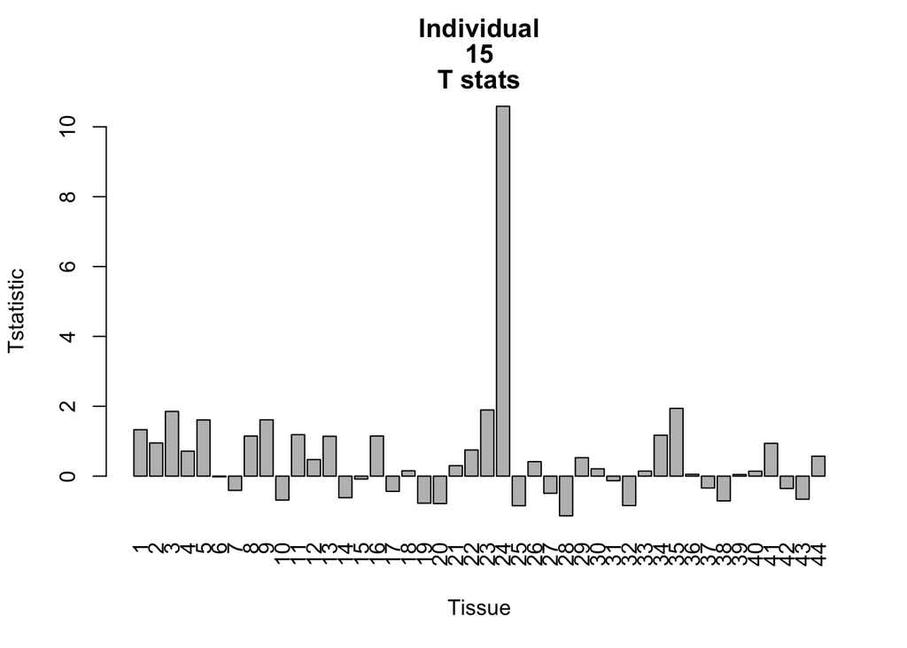

```r
barplot(data$tstat[j,],names=seq(1,44),las=3,xlab="Tissue",ylab="Tstatistic",main=paste(c("Individual",j,"T stats")))
```

```r
A="yourfavoritename"
covmat=readRDS(paste0("covmat",A,".rds"))
compute.hm.train.log.lik.pen(train.b = t[1:20000,],se.train = s.j[1:20000,],covmat = covmat,A=A,pen=10)
#Now, use compute.hm.train.log.lik for numerical issues
```

```r
A="yourfavoritename"
pis=readRDS(paste0("../simdata/pis",A,".rds"))$pihat

b.test=t[1:5000,]
se.test=s.j[1:5000,]
weightedquants=lapply(seq(1:10000),function(j){total.quant.per.snp(j,covmat,b.gp.hat=b.test,se.gp.hat = se.test,pis,A=A,checkpoint = FALSE)})
```

Let’s check some stuff out to make sure our computations are correct.

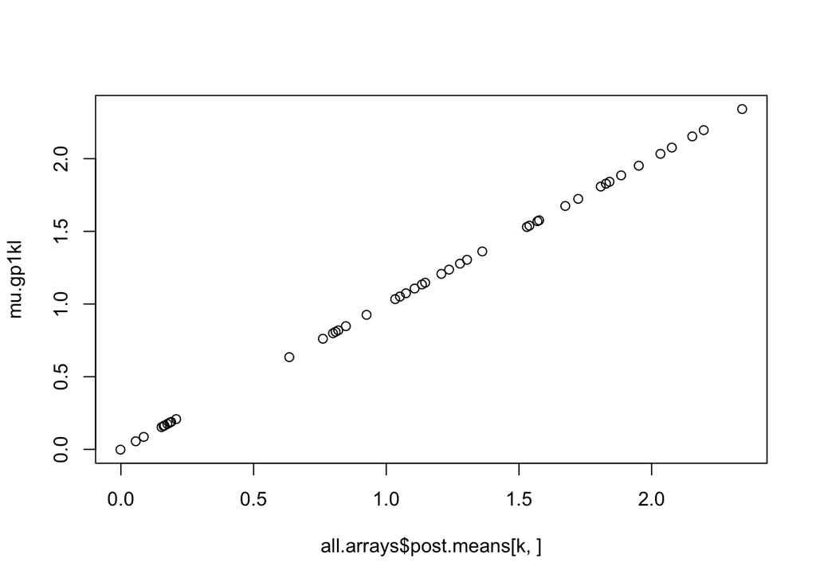

```r
j=sample.int(100,1)
A="yourfavoritename"
pis=readRDS(paste0("../simdata/pis",A,".rds"))$pihat
covmat=readRDS(paste0("../simdata/covmat",A,".rds"))
all.arrays=post.array.per.snp(j=j,covmat = covmat,b.gp.hat = t,se.gp.hat = v.j)

b.mle=as.vector(t(t[j,]))##turn i into a R x 1 vector
V.gp.hat=diag(s.j[j,])^2
V.gp.hat.inv <- solve(V.gp.hat)
k=3

U.gp1kl <- (post.b.gpkl.cov(V.gp.hat.inv, covmat[[k]]))
mu.gp1kl <- as.array(post.b.gpkl.mean(b.mle, V.gp.hat.inv, U.gp1kl))
#(all.arrays$post.means[k,])
plot(all.arrays$post.means[k,],mu.gp1kl)
```

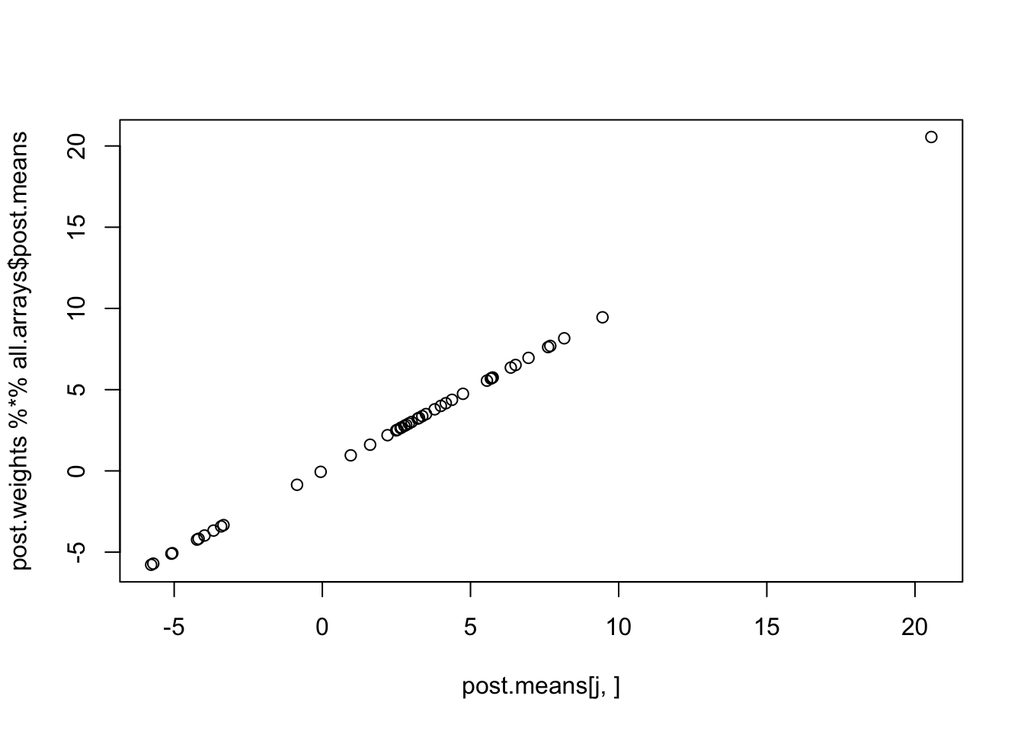

```r
##Now, check to make sure weighting is correct
post.means=as.matrix(read.table(paste0("../simdata/",A, "posterior.means.txt"))[,-1])
lik.snp=lik.func(b.mle,V.gp.hat,covmat)
post.weights=t(lik.snp*pis/sum(lik.snp*pis))

plot(post.means[j,],post.weights%*%all.arrays$post.means)
```

```r
#(post.means[j,])
#(post.weights[j,]%*%all.arrays$post.means)
```

Let’s take a tissue specific guy and see how well we estimate his posterior weight.

```r
library('mvtnorm')
#i=sample(seq(1:139),1)
i=24
(tspecindividual=which(data$component.id>8))
```

```
##   [1]   4   5   9  11  14  15  16  20  21  24  28  29  30  42  43  46  49
##  [18]  60  61  65  69  72  73  74  77  80  82  88  95 102 103 104 109 110
##  [35] 113 114 116 117 118 119 121 122 125 128 129 130 131 134 143 155 158
##  [52] 162 164 168 171 177 181 182 185 188 189 192 195 196 197 201 202 205
##  [69] 206 209 211 215 217 221 222 225 232 233 234 236 237 238 241 243 245
##  [86] 249 250 254 258 263 265 266 270 272 273 282 288 290 291 295 297 300
## [103] 309 310 311 315 316 318 323 331 333 342 343 344 347 349 350 361 368
## [120] 369 370 372 373 374 375 376 379 380 381 383 384 385 386 387 389 393
## [137] 394 399 400
```

```r
(j=tspecindividual[i])
```

```
## [1] 74
```

```r
(true.componenet=data$component.id[j])##determine which component he arose from
```

```
## [1] 10
```

```r
(tspec=which(diag(data$component.mats[[true.componenet]])!=0))###which tissue is that specific too
```

```
## [1] 14
```

```r
b.mle=as.vector(t(t[j,]))##turn i into a R x 1 vector
V.gp.hat=diag(s.j[j,])^2

lik.snp=lik.func(b.mle,V.gp.hat,covmat)
post.weights=t(lik.snp*pis/sum(lik.snp*pis))
pi.mat=matrix(pis[-length(pis)],ncol = 54,byrow = T)
pw.mat=matrix(post.weights[-length(pis)],ncol = 54,byrow = T)

###ask if the posterior weight at that componenet is higher than the prior weight, recognizing that we must add to the first 9 covmats
colSums(pi.mat)[tspec+9]
```

```
## [1] 0.001077985
```

```r
colSums(pw.mat)[tspec+9]
```

```
## [1] 1
```

We can see that our model is very good at capturing this tissue specific example!

Now let’s compare this to univariate ash measures:

```r
train.z=t[1:20000,]
train.v=s.j[1:20000,]

z.stat=t[1:5000,]
v.j=s.j[1:5000,]

univariate.ash.pm=matrix(nrow=nrow(z.stat),ncol=ncol(z.stat))
univariate.ash.lfsr=matrix(nrow=nrow(z.stat),ncol=ncol(z.stat))

R=ncol(z.stat)

for(x in 1:R){

b=ash(betahat=train.z[,x],sebetahat=train.v[,x],mixcompdist="normal")##fit weights on random data
g.fix=b$fitted.g
max.z.fit=ash(betahat=z.stat[,x], sebetahat=v.j[,x],g=g.fix,control=list(maxiter=0))
univariate.ash.pm[,x]=max.z.fit$PosteriorMean
univariate.ash.lfsr[,x]=max.z.fit$lfsr
}

write.table(univariate.ash.pm,file="uniashpm.txt")
write.table(univariate.ash.lfsr,file="uniashlfsr.txt")
```

Let’s compare the RMSE here between our multivariate and a univariate method. We want to compute the mean squared error of the effect, so we multiply by the standard error.

```r
data=readRDS("~/Dropbox/simdata_tspec.rds")
t=data$tstat;bhat=data$betahat;sebetahat=data$sebetahat;beta=data$beta;v.j=matrix(rep(1,ncol(t)*nrow(t)),ncol=ncol(t),nrow=nrow(t))
t.truth.test=beta/sebetahat
mash.means=as.matrix(read.table(paste0("../simdata/",A, "posterior.means.txt"))[,-1])
univariate.ash.pm=read.table("../simdata/uniashpm.txt")
standard=sqrt(mean((beta[1:5000,]-bhat[1:5000,])^2))
sqrt(mean((beta[1:5000,]-mash.means*sebetahat[1:5000,])^2))/standard
```

```
## [1] 0.1136403
```

```r
sqrt(mean((beta[1:5000,]-univariate.ash.pm[1:5000,]*sebetahat[1:5000,])^2))/standard
```

```
## [1] 0.3270584
```

We can also look at the covariance patterns learned:

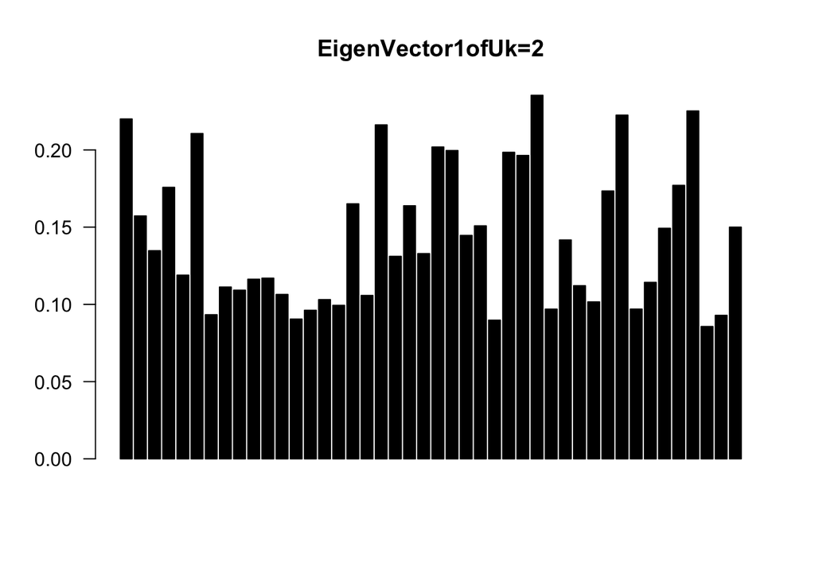

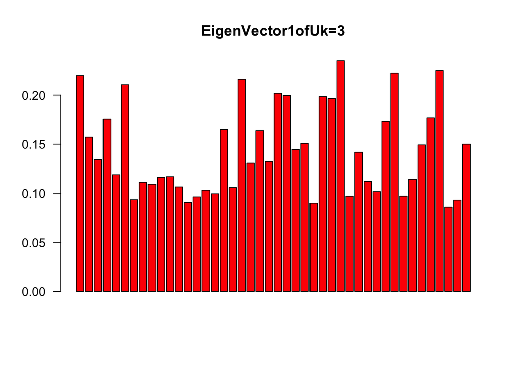

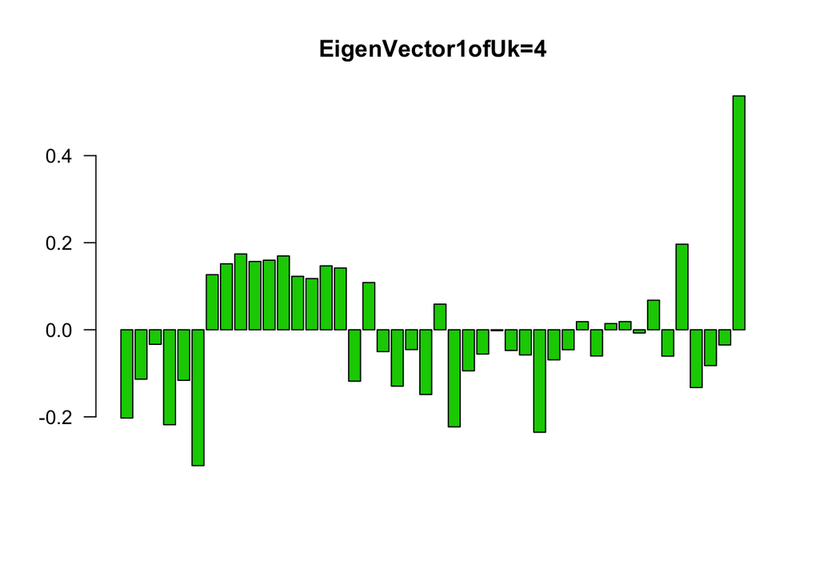

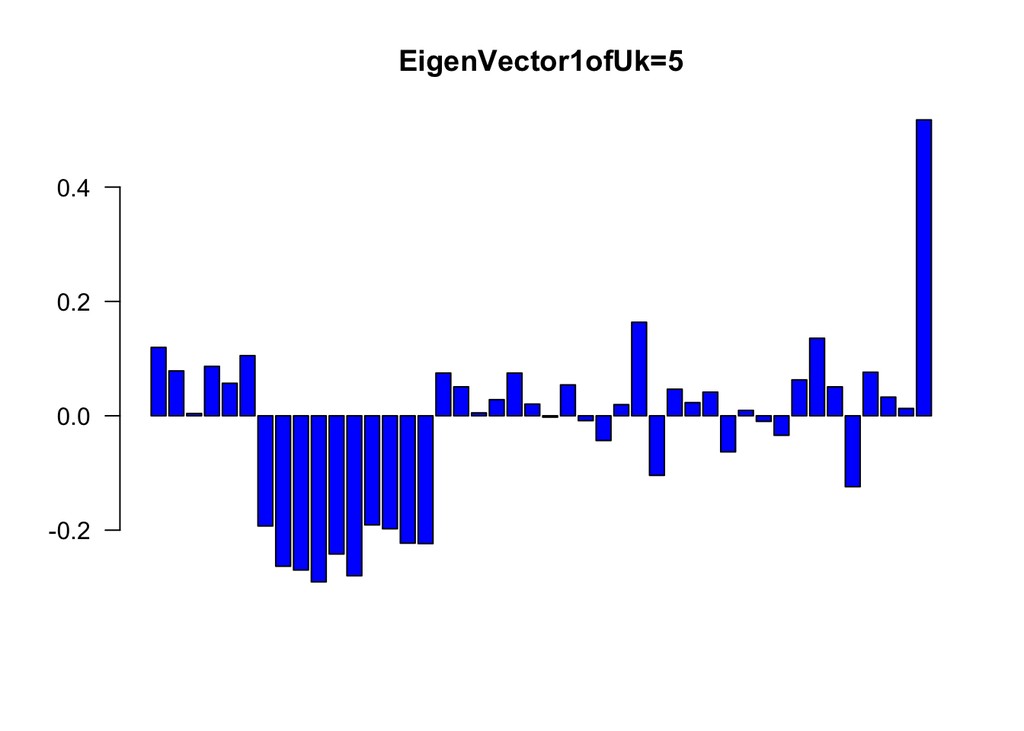

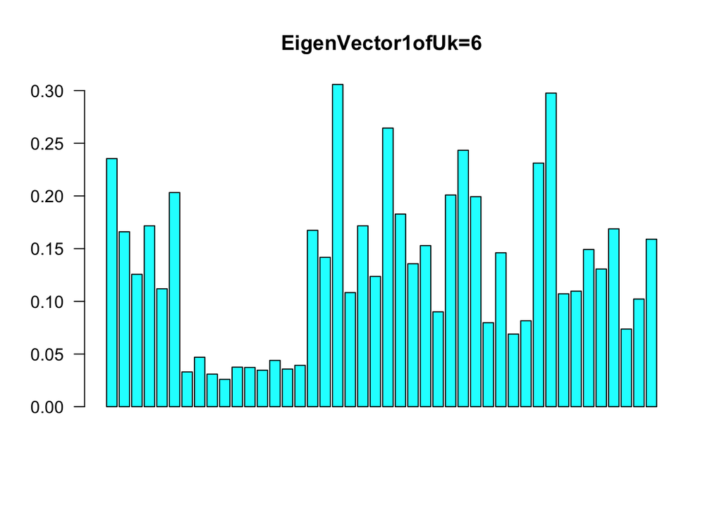

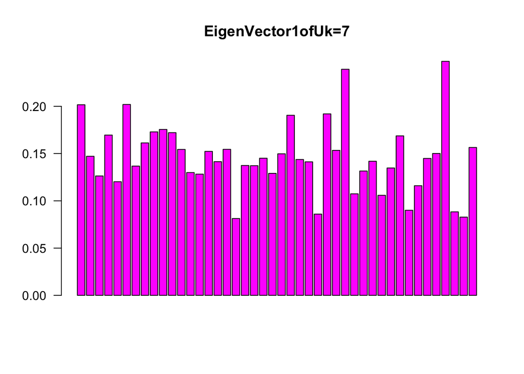

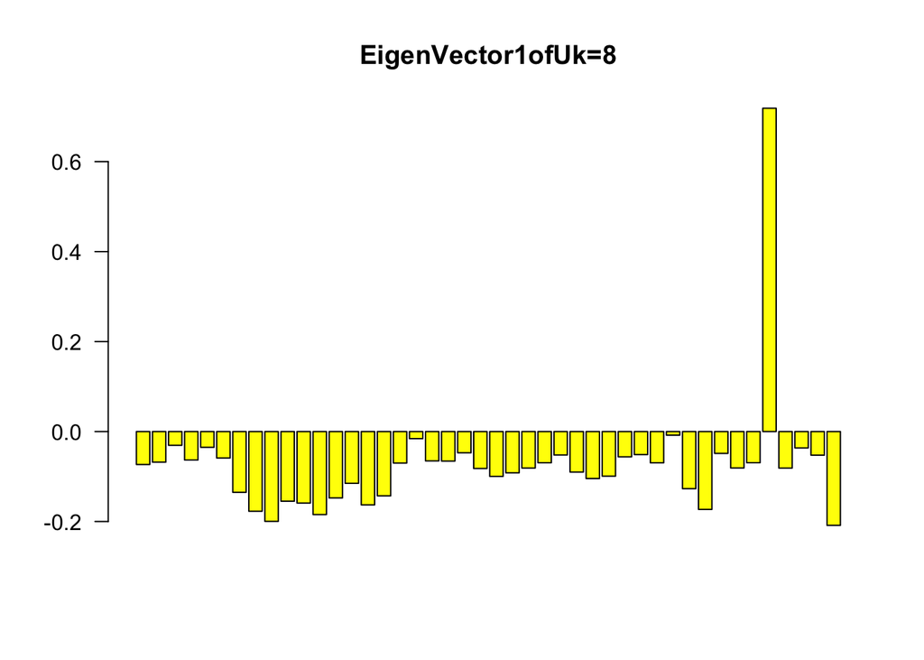

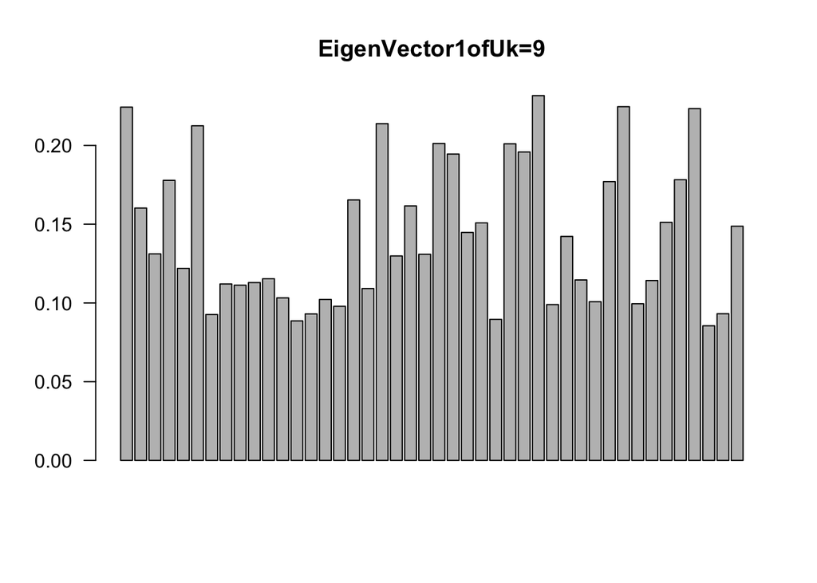

```r
for(i in c(2:9)){

v=svd(covmat[[i]])$v

max.effect=sign(v[,1][which.max(abs(v[,1]))])
barplot(max.effect*v[,1],las=2,main=paste0("EigenVector1ofUk=",i),col=i-1,cex.names=1)}
```

And here we plot number sig vs significance threshold:

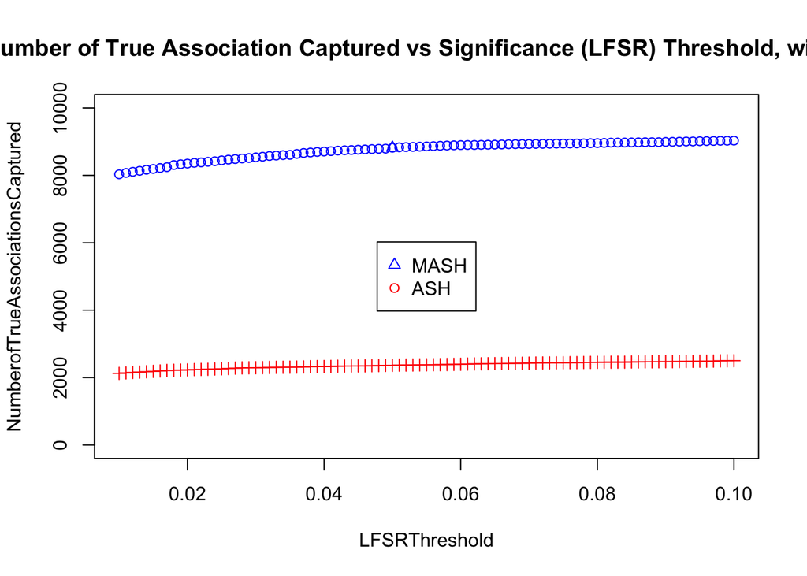